# Making My Own Functions: Check Regression Line- Comparison of Petal and Sepal Lengths / Widths

Claire

2020-01-22

We read in the desired dataset (preloaded to R):

```r
read.csv("iris.csv")
```

```
##     Sepal.Length Sepal.Width Petal.Length Petal.Width    Species
## 1            5.1         3.5          1.4         0.2     setosa
## 2            4.9         3.0          1.4         0.2     setosa
## 3            4.7         3.2          1.3         0.2     setosa
## 4            4.6         3.1          1.5         0.2     setosa
## 5            5.0         3.6          1.4         0.2     setosa
## 6            5.4         3.9          1.7         0.4     setosa
## 7            4.6         3.4          1.4         0.3     setosa
## 8            5.0         3.4          1.5         0.2     setosa
## 9            4.4         2.9          1.4         0.2     setosa
## 10           4.9         3.1          1.5         0.1     setosa
## 11           5.4         3.7          1.5         0.2     setosa
## 12           4.8         3.4          1.6         0.2     setosa
## 13           4.8         3.0          1.4         0.1     setosa
## 14           4.3         3.0          1.1         0.1     setosa
```

[output cut: 136 more lines]

We then defined objects:

```r
Slength <- iris$Sepal.Length
Plength <- iris$Petal.Length
x <- Slength
y <- Plength
lengths.lm <- lm(y~x)
coef(lengths.lm)
```

```
## (Intercept)           x
##   -7.101443    1.858433
```

```r
b <- coef(lengths.lm)
int <- b[1]
slope <- b[2]
```

**We then created a function that plots a dataset along with the x points along the line of regression. Then, we wanted to find the difference in y from the actual point to regression line. With this value, the sum of squared errors (sse) is calculated. Finally, the sse, slope, and y-intercept are added to the plot.**

```r
plotwithreg <- function(x=Slength, y=Plength, title="Sepal and Petal Morph", cxlab="Sepal Length", cylab="Petal Length", ccol=iris$Species, int=b[1], slope=b[2]) {

    plot(x, y, pch=10, col=ccol, main=title, xlab=cxlab, ylab=cylab)
    abline(int, slope, col="blue")

    yhat <- slope*x + int
    points(x, yhat)
    segments(x, y, x, yhat)

    error <- yhat - y #error in y from actual point to point on regression line
    error^2
    sse <- sum(error^2)
    sse #obtain sum of squared errors

    text(7.5,2, paste("sse=", round(sse, 2)))
    text(7.5,1.5, paste("slope=", round(slope, 2)))
    text(7.5,1, paste("intercept=", round(int, 2)))
    legend("topleft", legend=levels(iris$Species), col= c(1,2,3), pch=10)
}
```

I named the objects for the variables that I wanted to test:

```r
Slength <- iris$Sepal.Length
Plength <- iris$Petal.Length
```

*Finally, I used the function with default values.*

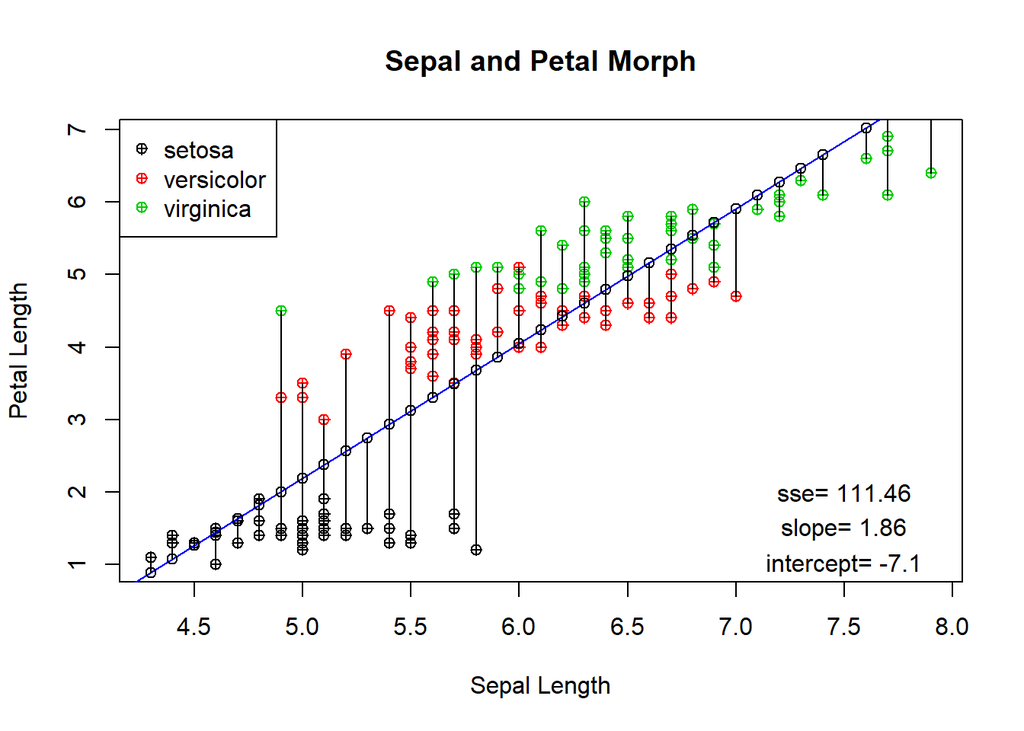

```r
plotwithreg()
```

*I then set x, y, and the labels to the default values to show that the function is working properly.*

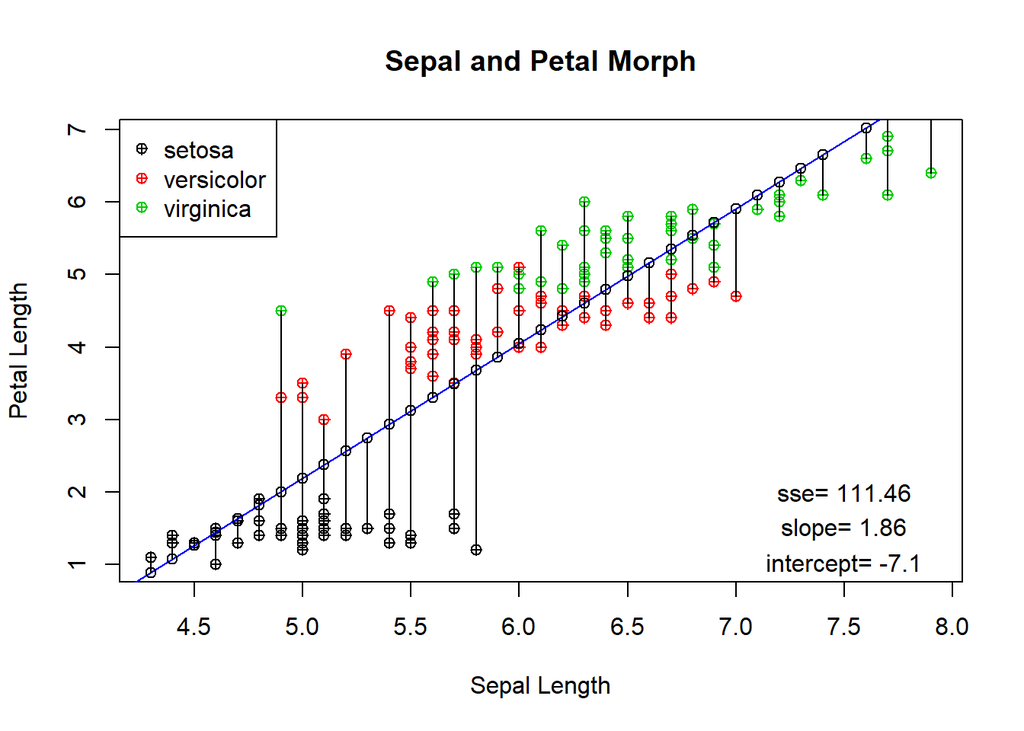

```r
plotwithreg(Slength, Plength, "Sepal and Petal Morph", "Sepal Length", "Petal Length")
```

*Tried it with arbitrary slopes and intercepts*

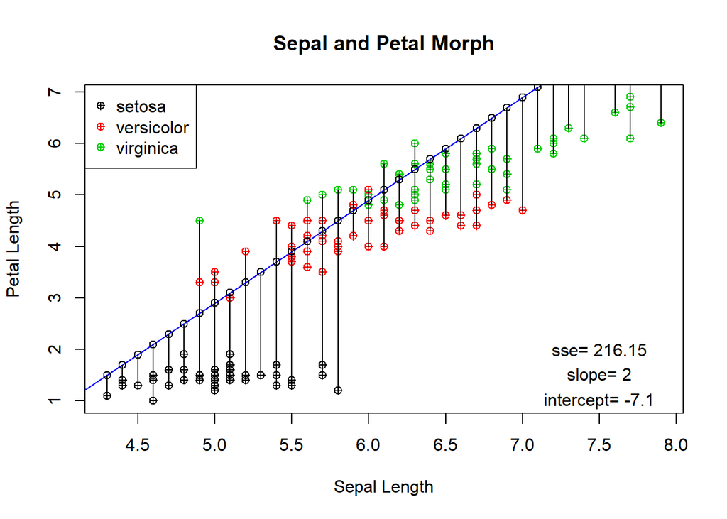

```r
plotwithreg(Slength, Plength, "Sepal and Petal Morph", "Sepal Length", "Petal Length", slope = 2)
```

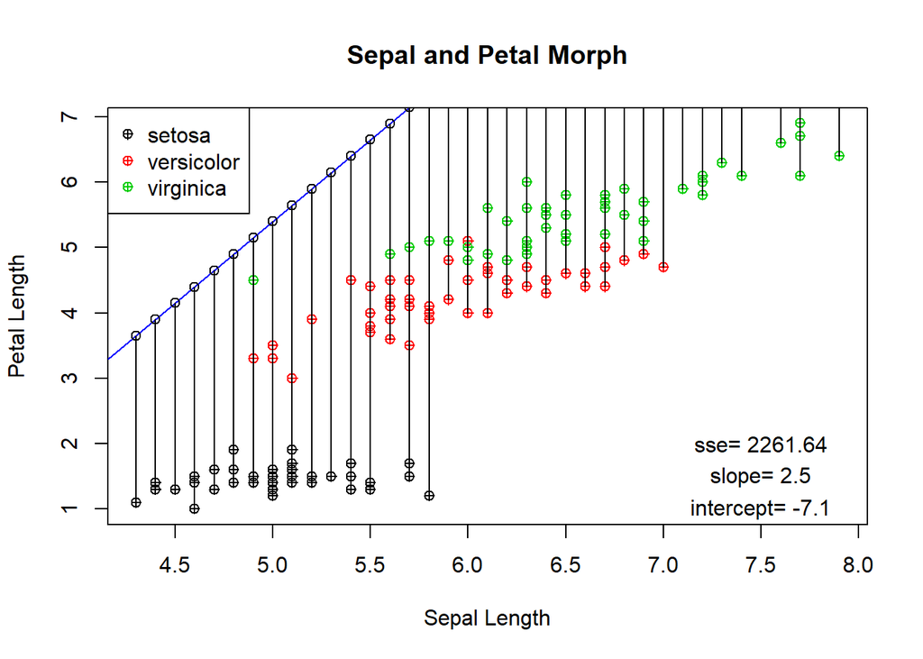

```r
plotwithreg(Slength, Plength, "Sepal and Petal Morph", "Sepal Length", "Petal Length", slope = 2.5)
```

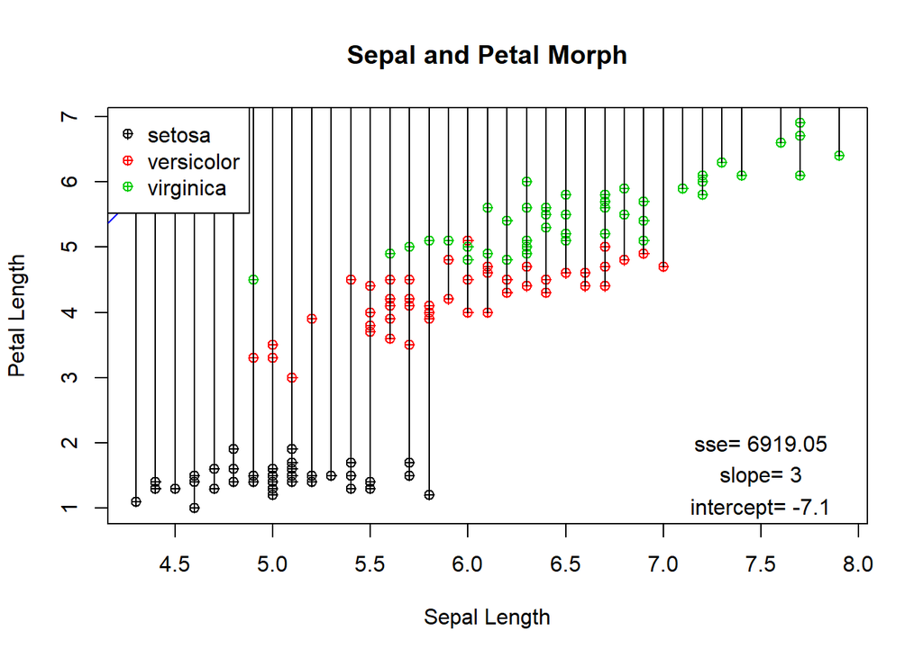

```r
plotwithreg(Slength, Plength, "Sepal and Petal Morph", "Sepal Length", "Petal Length", slope = 3)
```

I reset slope to observe only intercept change from dataset:

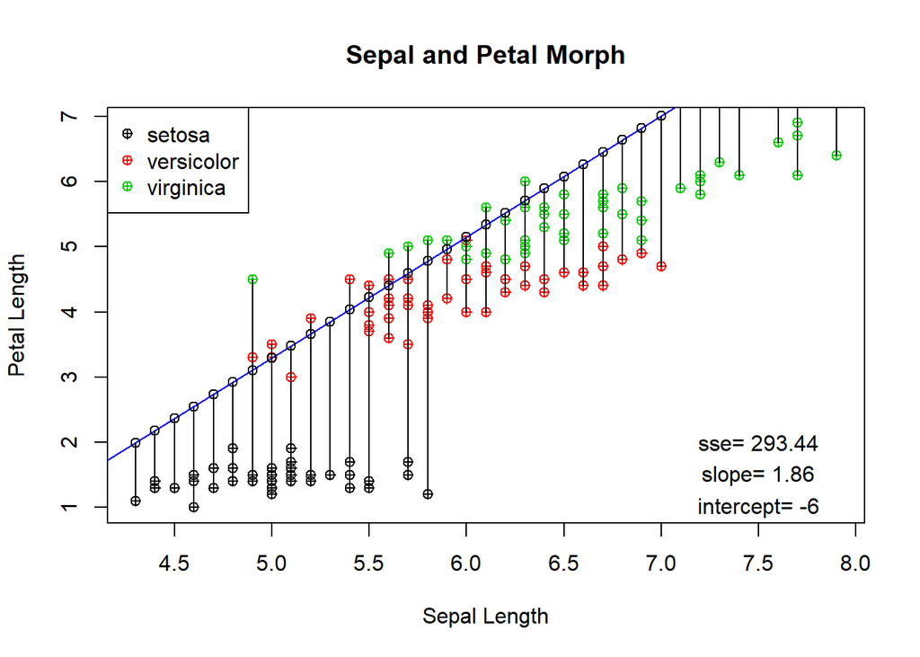

```r
slope <- b[2] #need to reset slope to observe only intercept change from dataset
plotwithreg(Slength, Plength, "Sepal and Petal Morph", "Sepal Length", "Petal Length", int = -6)
```

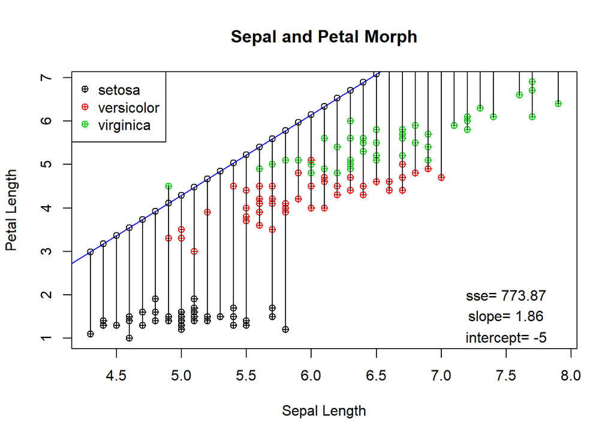

```r
plotwithreg(Slength, Plength, "Sepal and Petal Morph", "Sepal Length", "Petal Length", int= -5)
```

# My Function: Normalize

*I wanted to make a function that adjusted the petal width based on petal length.* First, I named the required objects:

```r
Species <- iris$Species
Plength <- iris$Petal.Length
Pwidth <- iris$Petal.Width
```

Then, I created a function called norm that divided the y values by a set length(leng) and plots the results per species.

```r
norm <- function(x=1, y=2, title="Normalized", cxlab="x", cylab="y") {
y <- y/leng
plot(Species, y, main=title, xlab=cxlab, ylab=cylab, col= c(5,6,7))
}
```

Finally, the lengths(leng) are defined and vectors for x, y, and labels are used in the norm function.

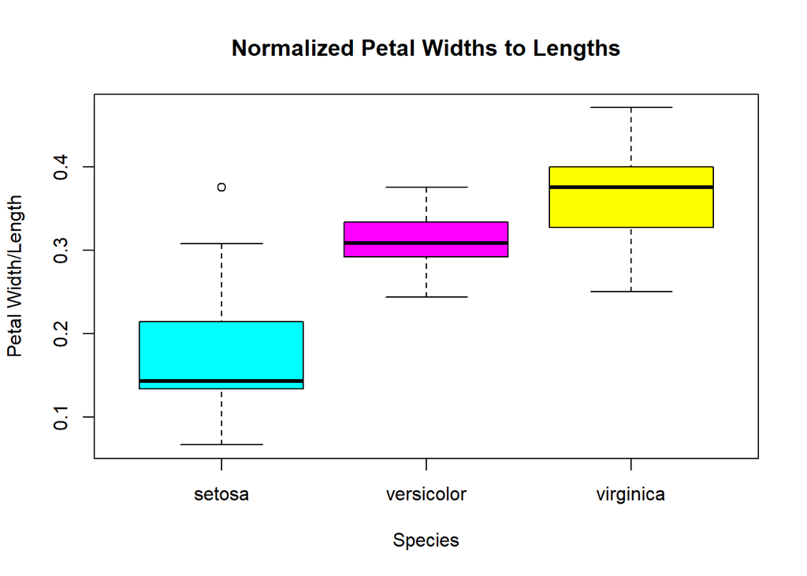

```r
leng <- Plength
norm(Species, Pwidth, "Normalized Petal Widths to Lengths", "Species", "Petal Width/Length")
```